# Eine explorative Datenanalyse von #breakfreefromplastic

Nina Hauser

25. March 2022

```
## [1] "C"
```

[figure not shown]

### Vorwort

Im Folgenden soll der Datensatz der **Break Free From Plastic** Bewegung für das Jahr 2019 und 2020 explorativ erkundet werden. Der Datensatz enthält 13.380 Beobachtungen zu Plastiksammelaktionen in 69 Ländern. Enthalten sind die Variablen (als Stichpunkte): Land, Jahr, Hersteller des Produktes, Art des gesammelten Plastiks sowie die Anzahl an durchgeführten Events und der Anzahl teilnehmender Freiwilliger.

*Anmerkung: Mehr Informationen zu Break Free From Plastic finden Sie unter diesem [Link](https://www.breakfreefromplastic.org/)*.

### Datenbereinigung

Im Jahr 2020 konnten nur wenige Events durchgeführt werden. Nach Betrachtung der Datenlage wurde das Jahr 2020 deshalb von der Analyse ausgeschlossen. Auch wurde der Datensatz in zwei Tabellen aufgeteilt: Daten zum Plastikaudit und Daten aus der Gemeinschaft rund um die Bewegung. Nach der Datenbereinigung verblieben noch Daten aus 51 Ländern und zu 7.131 Herstellern im Datensatz, wobei eine Beobachtung im ersten Datensatz einem Land, im zweiten einer einzigartigen Land-Hersteller-Plastikart-Kombination entspricht. Es handelt sich somit stets um **aggregierte Daten** der Länderbüros.

[interactive chart not shown]

### Thematische Einordnung

Die Herausforderung, die Break Free From Plastic lösen möchte, ist eng verknüpft mit dem **zwölften Ziel für nachhaltige Entwicklung, den Sustainable Development Goals** (kurz: SDGs). Ziel 12 setzt sich für “Verantwortungsvolle Konsum- und Produktionsmuster” ein. Konkret geht es insbesondere in Punkt 12.5 um die Reduktion von Abfall durch Prävention, Reduktion, Recycling und Wiederverwendung. Indikator 12.5.1 stellt dabei die nationalen Recyclingraten in Prozent dar. Besonders Plastik ist in der derzeitigen Konsumlandschaft ein immenses Problem: Als oftmals nur einmalig genutztes und langlebiges Abfallprodukt mit niedrigen Recyclingquoten verschmutzt es die Welt zu Land und zu Wasser und nimmt dort erheblichen **Einfluss auf die Flora und Fauna**. Weltweit sind 73 Prozent des Strandmülls Plastikprodukte, während im Meer schätzungsweise mehr als 5 Trillionen Plastikstücke schwimmen. Deren Anzahl wächst mit der Produktion von Plastik exponentiell: Bis 2015 betrug die Produktion mehr als 6,3 Milliarden Tonnen, von denen nur 9 Prozent recycelt wurden. Davon wurden 2015 406 Millionen produziert, 1950 waren es noch 2,1 und 1993 147 Millionen ([Quelle: National Geographic UK](https://www.nationalgeographic.co.uk/10-shocking-facts-about-plastic)). Wollen wir unsere Umwelt erhalten, müssen wir die Pflanz- und Tierwelt vor Produkten schützen, deren Zersetzung zu Mikroplastik 450 Jahre (und mehr) beträgt. Ein vollständiger Abbau ist grundsätzlich nicht möglich. Umso wichtiger, dass die bereits in der freien Natur vorkommenden Plastikstücke gesammelt und ordnungsgemäß entsorgt werden. In welchem Umfang Break Free From Plastic dazu beitragen konnte, soll hier vorgestellt werden.

### Aktivitäten

2019 führte Break Free From Plastics 338 Events mit 70.820 Freiwilligen durch, kategorisierte die verschiedenen Plastikstücke und sorgte im Anschluss für ihre fachgerechte Entsorgung. Besonders häufig waren Plastikstücke der Firmen La Doo, The Coca-Cola Company und Barna.

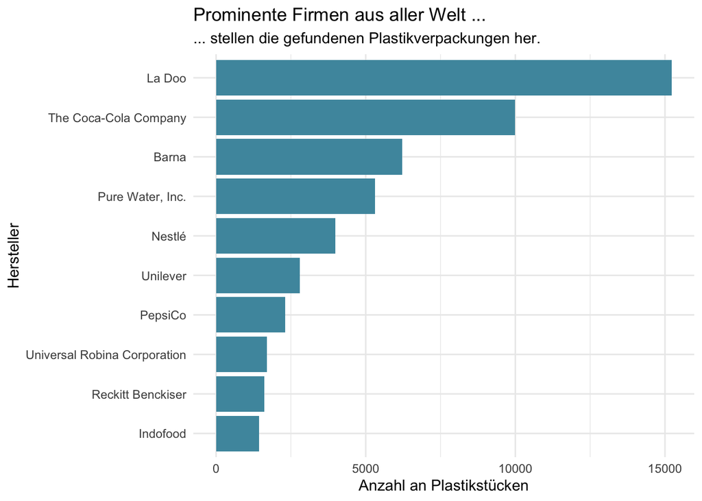

### Effekte und Wirkungen

Insgesamt wurden auf **338 Events** mit durchschnittlich **102 Freiwilligen** im Schnitt 375 Plastikstücke gesammelt. Das entspricht insgesamt **372.276 Plastikstücken**.

Übersicht über Events und Freiwillige

| Kontinent | Anzahl Länder | Anzahl Events | Anzahl Freiwilliger | Anzahl Plastikstücke |
| --- | --- | --- | --- | --- |
| Afrika | 11 | 61 | 9486 | 112717 |
| Amerika | 7 | 59 | 7167 | 25926 |
| Asien | 17 | 169 | 51675 | 204051 |
| Europa | 15 | 48 | 2487 | 29579 |
| Ozeanien | 1 | 1 | 5 | 3 |

In **Taiwan** wurden die meisten Menschen zur Teilnahme bewegt (n = 31.318). Besonders viele Plastikstücke wurden in **Taiwan** (n = 120.646) gesammelt. Die Beteiligung sowie die Anzahl an gesammeltem Plastik fluktuiert stark zwischen den Ländern.

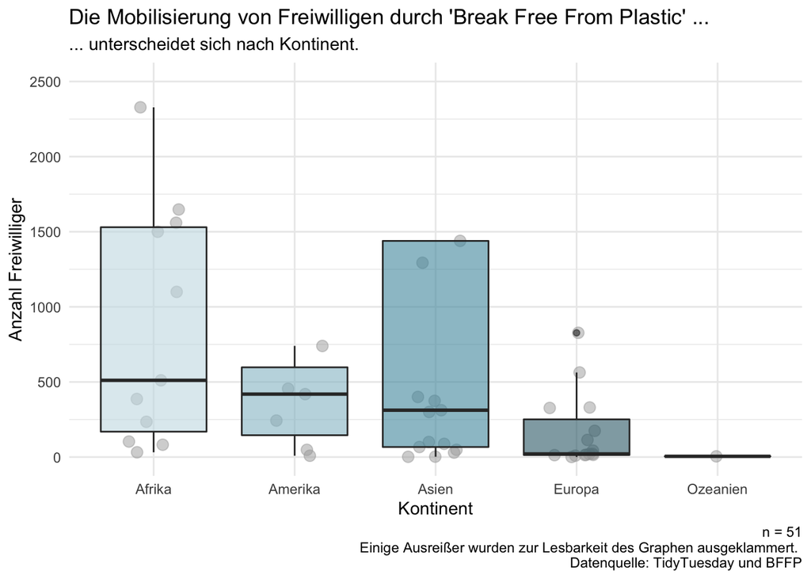

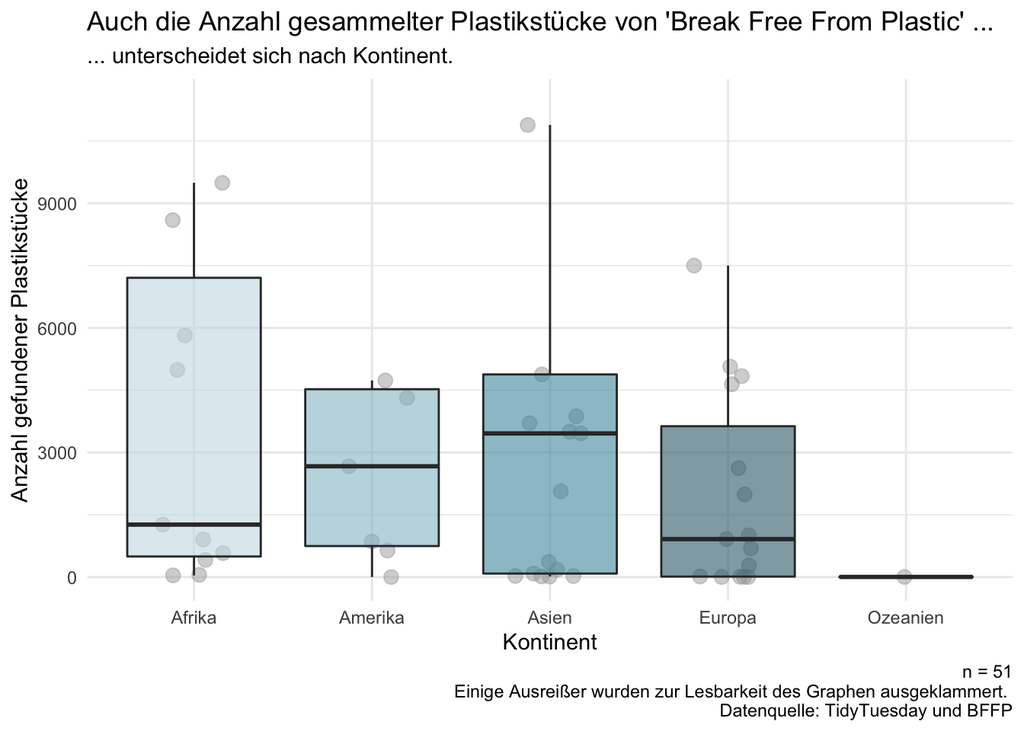

### Ausblick

Die Anzahl der Events korreliert nur sehr schwach mit der Anzahl gesammelter Plastikstücke (Korrelation: 0.08). Über den Zusammenhang zwischen der Anzahl der gesammelten Plastikstücke und den Freiwilligen können wir auf Grund der Aggregation der Daten keine statistische Aussage treffen. Spannend könnte hier deshalb eine genauere Betrachtung dieses Zusammenhanges sein. Es ist jedenfalls auffällig, dass in einigen Ländern viele Freiwillige zusammenkamen, aber nur wenig Plastikstücke gesammelt wurden. Warum das so ist, sollte in Gesprächen mit Organisator:innen geprüft werden. In Betracht kommen hier Fehler beim Reporting, das für die politische Arbeit der Bewegung allerdings zentral ist, oder Events, in denen das Sammeln von Plastik nicht im Vordergrund stand (beispielsweise da sie der Aufklärung dienten).

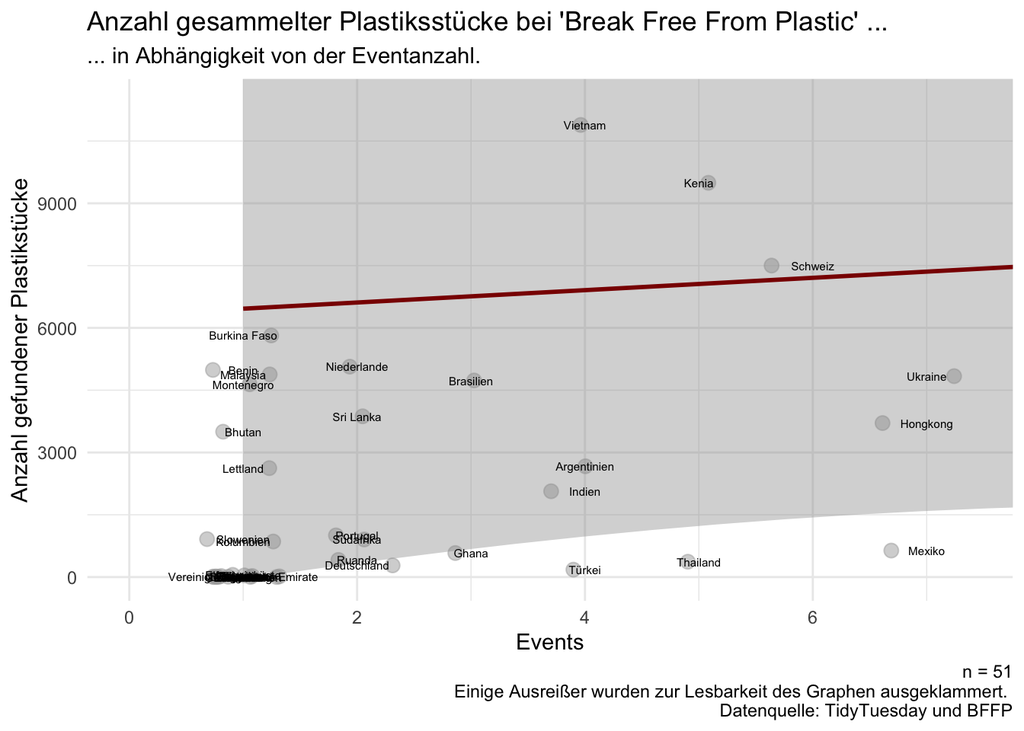